# Homework #1

#### Computing ID: cx2rx

**SYS 6018 | Fall 2020 | University of Virginia**

### Problem 1.1: Evaluating a Regression Model

1. Create a set of functions to generate data from the following distributions:
   $$\begin{align*}
   X &\sim \mathcal{N}(0, 1) \\
   Y &= -1 + .5X + .2X^2 + \epsilon \\
   \epsilon &\sim \mathcal{N}(0,\, \sigma)
   \end{align*}$$

```r
X <- function(n, mean = 0, sd = 1) {
  return(rnorm(n, mean = mean, sd = sd))
}

epsilon <- function(n, mean = 0, sigma) {
  return(rnorm(n, mean = mean, sd = sigma))
}

Y <- function(x, error) {
  return(-1 + 0.5 * x + 0.2 * x^2 + error)
}
```

2. Simulate $n=100$ realizations from these distributions using $\sigma=3$. Produce a scatterplot and draw the true regression line $f(x) = E[Y \mid X=x]$. Use `set.seed(611)` prior to generating the data.

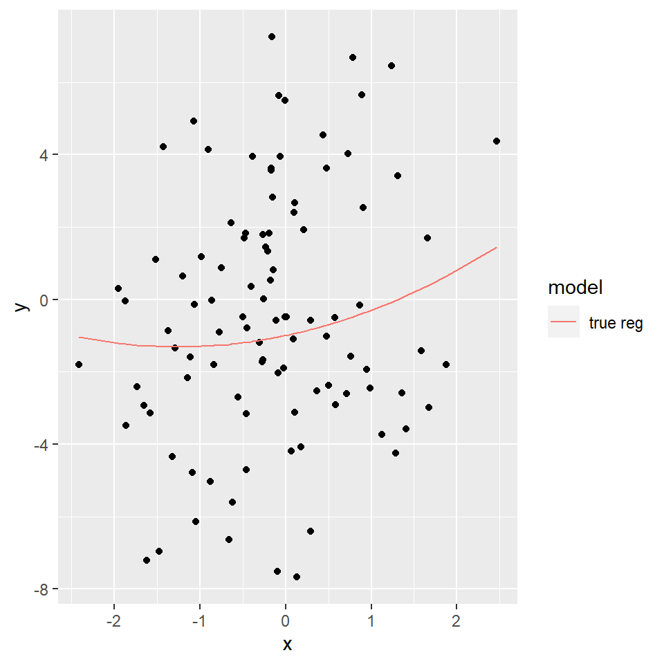

```r
# Set Seed
set.seed(611)

# Parameters
n = 100
sigma = 3

# Distributions
X_dist <- X(n)
Eps_dist <- epsilon(n, sigma = sigma)
Y_dist <- Y(x = X_dist, error = Eps_dist)

# Create a Data Frame for graphing
df <- data.frame(x = X_dist, y = Y_dist)

# Create the scatter plot
ggbase <- ggplot(data = df, aes(x = x, y = y)) +
  geom_point()

ggbase +
  geom_line(aes(y = Y(x, 0), color = "true reg")) +
  scale_color_discrete(name="model")
```

3. Fit three polynomial regression models using least squares: linear, quadratic, and cubic. Produce another scatterplot, add the fitted lines and true population line $f(x)$ using different colors, and add a legend that maps the line color to a model.
   - Note: Notice that while the true model is quadratic, we are also fitting linear (less complex) and cubic (more complex) models.

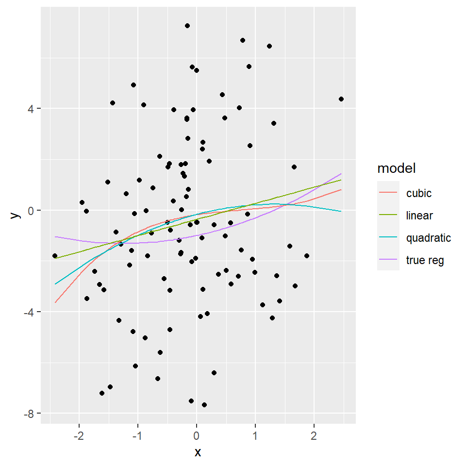

```r
cubic <- lm(y ~ poly(x, 3), data = df)
quadratic <- lm(y ~ poly(x, 2), data = df)
linear <- lm(y ~ x, data = df)

df <- df %>%
  mutate(y_cubic = cubic$fitted.values,
         y_quadratic = quadratic$fitted.values,
         y_linear = linear$fitted.values)

# Add additional regression lines to the base plot
ggbase +
  geom_line(aes(y = Y(x, 0), color = "true reg")) +
  geom_line(aes(y = y_cubic, color = "cubic"), data = df) +
  geom_line(aes(y = y_quadratic, color = "quadratic"), data = df) +
  geom_line(aes(y = y_linear, color = "linear"), data = df) +
  scale_color_discrete(name="model")
```

4. Simulate a test data set of $10000$ observations from the same distributions. Use `set.seed(612)` prior to generating the test data. Calculate the estimated mean squared error (MSE) for each model. Are the results as expected?

```r
# Set Seed
set.seed(612)

# Pre-defined parameter
n = 10000
sigma = 3

# New test data
x_test = X(n)
eps_test = epsilon(n, sigma = sigma)
y_test = Y(x_test, eps_test)

# Create a test data frame
test <- data.frame(x = x_test, y = y_test)

# Calculate the estimated MSE for each model
yhat_cubic <- predict(cubic, newdata = test)
yhat_quadratic <- predict(quadratic, newdata = test)
yhat_linear <- predict(linear, newdata = test)

mse <- data.frame(Model = c("cubic", "quadratic", "linear"),
                  # `Training MSE` = c(mean((cubic$residuals) ^ 2),
                  #                    mean((quadratic$residuals) ^ 2),
                  #                    mean((linear$residuals) ^ 2)),
                  `Testing MSE` = c(mean((test$y - yhat_cubic)^ 2),
                                    mean((test$y - yhat_quadratic) ^ 2),
                                    mean((test$y - yhat_linear) ^ 2)))
print(mse)
```

```
#>       Model Testing.MSE
#> 1     cubic    9.648192
#> 2 quadratic    9.583155
#> 3    linear    9.293776
```

5. What is the best achievable MSE? That is, what is the MSE if the true $f(x)$ was used to evaluate the test set? How close does the best method come to achieving the optimum?

```r
# Calculate the MSE for the true f(x)
y_true_reg <- -1 + 0.5* x_test + 0.2 * x_test^2
mse_true_reg <- mean((test$y - y_true_reg)^2)

# Print the values
print(mse_true_reg)
```

```
#> [1] 8.972119
```

```r
print(min(mse$Testing.MSE) - mse_true_reg)
```

```
#> [1] 0.3216562
```

The MSE for the true $f(x)$ is 8.972119. The best method has a 9.293776 MSE, which is 0.3216562 greater than the optimal MSE.

6. The MSE scores obtained in part *d* came from one realization of training data. Here will we explore how much variation there is in the MSE scores by replicating the simulation many times.
   - Re-run the same simulation in part *d* 100 times.
   - Create kernel density plots (you choose bandwidth) of the resulting MSE values for each model.
   - Use `set.seed(613)` prior to running the simulation and do not set the seed in any other places.

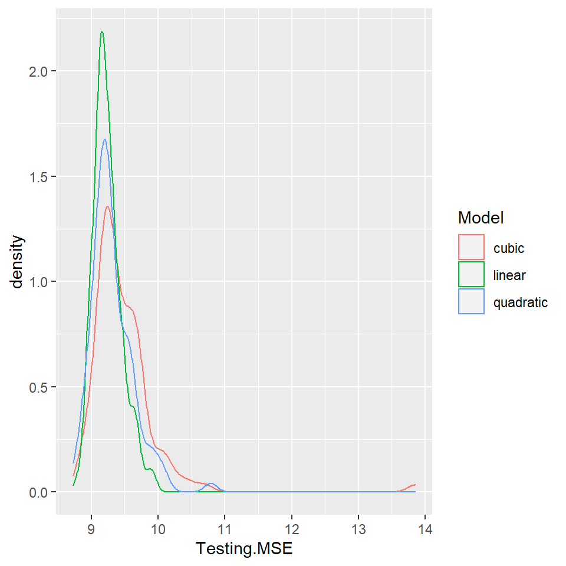

```r
# Set Seed
set.seed(613)

output <- list()

for (i in 1:100) {
  # Training Parameters
  n = 100

  # Distributions
  X_dist <- X(n)
  Eps_dist <- epsilon(n, sigma = sigma)
  Y_dist <- Y(x = X_dist, error = Eps_dist)

  # Create a Data Frame for graphing
  df <- data.frame(x = X_dist, y = Y_dist)

  # Re-run modeling with new training data
  cubic <- lm(y ~ poly(x, 3), data = df)
  quadratic <- lm(y ~ poly(x, 2), data = df)
  linear <- lm(y ~ x, data = df)


  # Testing Parameters
  n = 10000

  # New test data
  x_test = X(n)
  eps_test = epsilon(n, sigma = sigma)
  y_test = Y(x_test, eps_test)

  # Create a test data frame
  test <- data.frame(x = x_test, y = y_test)

  # Calculate the estimated MSE for each model
  yhat_cubic <- predict(cubic, newdata = test)
  yhat_quadratic <- predict(quadratic, newdata = test)
  yhat_linear <- predict(linear, newdata = test)

  # Create an MSE Table to print
  mse <- data.frame(Model = c("cubic", "quadratic", "linear"),
                    `Testing MSE` = c(mean((test$y - yhat_cubic)^ 2),
                                      mean((test$y - yhat_quadratic) ^ 2),
                                      mean((test$y - yhat_linear) ^ 2)),
                    Run = i)
  # Store the MSE Table in the designated list
  output[[i]] <- mse
}

# Convert list to data frame
output <- bind_rows(output)

# Create the Density Plot for Each Model Testing MSE
ggplot(data = output, aes(x = Testing.MSE, color = Model)) +
  geom_density(alpha=.5)
```

7. Show a count of how many times each model was the best. That is, out of the 100 simulations, count how many times each model had the lowest MSE.

```r
# Count of how many times each model was the best
output %>%
  group_by(Run) %>%
  summarise(Testing.MSE = min(Testing.MSE)) %>%
  left_join(output, by = c('Run', "Testing.MSE")) %>%
  group_by(Model) %>%
  summarise(Count = n())
```

```
#> # A tibble: 3 x 2
#>   Model     Count
#>   <fct>     <int>
#> 1 cubic         6
#> 2 linear       44
#> 3 quadratic    50
```

8. Repeat the simulation in part *g*, but use $\sigma=2$. Report the number of times each model was best (you do not need to produce any plots). Use the same `set.seed(613)` prior to running the simulation and do not set the seed in any other places.

```r
# Set Seed
set.seed(613)

# New sigma value
sigma = 2

# Create a empty list to store output
output <- list()

for (i in 1:100) {
  # Training Parameters
  n = 100

  # Distributions
  X_dist <- X(n)
  Eps_dist <- epsilon(n, sigma = sigma)
  Y_dist <- Y(x = X_dist, error = Eps_dist)

  # Create a Data Frame for graphing
  df <- data.frame(x = X_dist, y = Y_dist)

  # Re-run modeling with new training data
  cubic <- lm(y ~ poly(x, 3), data = df)
  quadratic <- lm(y ~ poly(x, 2), data = df)
  linear <- lm(y ~ x, data = df)


  # Testing Parameters
  n = 10000

  # New test data
  x_test = X(n)
  eps_test = epsilon(n, sigma = sigma)
  y_test = Y(x_test, eps_test)

  # Create a test data frame
  test <- data.frame(x = x_test, y = y_test)

  # Calculate the estimated MSE for each model
  yhat_cubic <- predict(cubic, newdata = test)
  yhat_quadratic <- predict(quadratic, newdata = test)
  yhat_linear <- predict(linear, newdata = test)

  # Create an MSE Table to print
  mse <- data.frame(Model = c("cubic", "quadratic", "linear"),
                    `Testing MSE` = c(mean((test$y - yhat_cubic)^ 2),
                                      mean((test$y - yhat_quadratic) ^ 2),
                                      mean((test$y - yhat_linear) ^ 2)),
                    Run = i)
  # Store the MSE Table in the designated list
  output[[i]] <- mse
}

# Convert list to data frame
output <- bind_rows(output)

# Count of how many times each model was the best
output %>%
  group_by(Run) %>%
  summarise(Testing.MSE = min(Testing.MSE)) %>%
  left_join(output, by = c('Run', "Testing.MSE")) %>%
  group_by(Model) %>%
  summarise(Count = n())
```

```
#> # A tibble: 3 x 2
#>   Model     Count
#>   <fct>     <int>
#> 1 cubic         8
#> 2 linear       26
#> 3 quadratic    66
```

1. Repeat *g*, but now use $\sigma=4$ and $n=200$.

```r
# Set Seed
set.seed(613)

# New sigma value
sigma = 4

# Create a empty list to store output
output <- list()

for (i in 1:100) {
  # Training Parameters
  n = 200

  # Distributions
  X_dist <- X(n)
  Eps_dist <- epsilon(n, sigma = sigma)
  Y_dist <- Y(x = X_dist, error = Eps_dist)

  # Create a Data Frame for graphing
  df <- data.frame(x = X_dist, y = Y_dist)

  # Re-run modeling with new training data
  cubic <- lm(y ~ poly(x, 3), data = df)
  quadratic <- lm(y ~ poly(x, 2), data = df)
  linear <- lm(y ~ x, data = df)


  # Testing Parameters
  n = 10000

  # New test data
  x_test = X(n)
  eps_test = epsilon(n, sigma = sigma)
  y_test = Y(x_test, eps_test)

  # Create a test data frame
  test <- data.frame(x = x_test, y = y_test)

  # Calculate the estimated MSE for each model
  yhat_cubic <- predict(cubic, newdata = test)
  yhat_quadratic <- predict(quadratic, newdata = test)
  yhat_linear <- predict(linear, newdata = test)

  # Create an MSE Table to print
  mse <- data.frame(Model = c("cubic", "quadratic", "linear"),
                    `Testing MSE` = c(mean((test$y - yhat_cubic)^ 2),
                                      mean((test$y - yhat_quadratic) ^ 2),
                                      mean((test$y - yhat_linear) ^ 2)),
                    Run = i)
  # Store the MSE Table in the designated list
  output[[i]] <- mse
}

# Convert list to data frame
output <- bind_rows(output)

# Count of how many times each model was the best
output %>%
  group_by(Run) %>%
  summarise(Testing.MSE = min(Testing.MSE)) %>%
  left_join(output, by = c('Run', "Testing.MSE")) %>%
  group_by(Model) %>%
  summarise(Count = n())
```

```
#> # A tibble: 3 x 2
#>   Model     Count
#>   <fct>     <int>
#> 1 cubic        10
#> 2 linear       23
#> 3 quadratic    67
```

10. Describe the effects $\sigma$ and $n$ has on selection of the best model? Why is the *true* model form (i.e., quadratic) not always the *best* model to use when prediction is the goal?
- From part (h), we know that when reducing the value of $\sigma$, the number of times that quadratic model wins increases. It is telling us that when the variability of the training and testing data decreases, our simulation tends to agree more with the true regression setting. When we increase $\sigma$ and training sample size $n$ at the same time, we are increasing the variability, but we have more training data to fit the model as well. In this case, we see that, even though the variability increases, more training data helps the quadratic model to win 67% of the time. This is telling us that the more training data we have, it is more likely that our simulation tends to agree more with the true regression setting, even with a lot of variability in the data.
- The reason why the true model does not always win is mainly because of the irreducible error term $\epsilon$. $\epsilon$ introduces a lot of variability into the training and testing data, so the final distribution of the training and testing data can vary dramatically from the true regression line, as we can see in the first scatterplot above. Therefore, for some occasions, quadratic form may not be the best model, comparing to linear and cubic models.